# msdr

The goal of msdr is to provide conveniance functions to analyse [NOAA Significant Earthquakes dataset](https://www.ngdc.noaa.gov/hazel/view/hazards/earthquake/search).

The package contains three main sets of functions: 1. Cleaning functions 2. Plotting functions (in the form of [ggplot2](https://ggplot2.tidyverse.org/) geoms) 3. Mapping functions

The package contains an example dataset that can be access with msdr::raw_noaa

## Installation and loading

You can install the released version of msdr from [github](https://github.com/ElliottMess/msdr) with:

```r
devtools::install_github("ElliottMess/msdr")
```

It can then be easily loaded with

```r
library(msdr)
```

## Cleaning functions

There is two cleaning function: 1. eq_location_clean() 2. eq_clean_data()

eq_location_clean cleans the location names to provide more informative labels.

eq_clean_data formates the whole dataset to implement better data management, including calling eq_location_clean on the location column.

```r
clean_location_noaa <- eq_location_clean(raw_noaa)

test <- eq_clean_data(raw_noaa)
```

## Plotting functions

Two plotting functions exist: 1. geom_timeline 2. geom_timeline_label

geom_timeline creates a timeline representation of the data by date.

It plots earthquakes on a timeline ranging from a minimum (xmin) to a maximum (xmax). Each point is an earthquake. The x aesthetic is a Date class vector of dates of earthquakes. Size, colour, alpha and y can be provided as optional aesthetic. y must be a factor and can be used to have one timeline per level of the factor. For instance, each line can be a country.

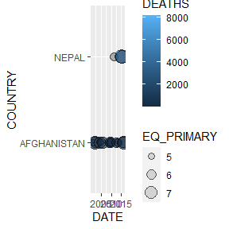

```r
library(ggplot2)
clean <- eq_clean_data(raw_noaa) %>%
  filter(COUNTRY %in% c("AFGHANISTAN", "NEPAL"))

ggplot(clean, aes(x = DATE, y = COUNTRY, size=EQ_PRIMARY, fill = DEATHS)) +
     geom_timeline(alpha = 0.6, xmin = ymd('2000-01-01'), xmax = ymd('2015-12-31'))
```

geom_timeline_label adds a label to each data point that consists of a line and a text (for instance, the location of the earthquake) attached to each line. The x aesthetic provides the date vector for the timeline and label provides the labelling vector. The top_eq convienence function helps find the n_max optional parameter allows to subset the data with the n_max largest earthquakes by magnitude.

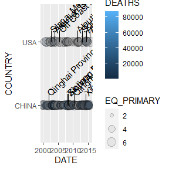

```r
library(dplyr)
library(ggplot2)
library(lubridate)
data <- eq_clean_data(raw_noaa) %>%
        filter(COUNTRY %in% c('USA', 'CHINA'))

labels <- data %>%
  top_eq(n_max = 10, min_date = ymd('2000-01-01'), max_date = ymd('2015-12-31'))

ggplot(data, aes(x = DATE, y = COUNTRY, fill = DEATHS)) +
  geom_timeline(aes(size = EQ_PRIMARY), alpha = 0.25,
                    xmin = ymd('2000-01-01'), xmax = ymd('2015-12-31')) +
  geom_timeline_label(data = labels,
                      mapping = aes(x = DATE, y = COUNTRY, label = LOCATION_NAME))
```

## Mapping functions

The mapping functions allows to explore on a map the datasets. There is two mapping functions:

1. eq_map()
2. eq_create_label()

eq_map() creates maps based on the dataset provided, while eq_create_label() creates more informative label for eq_map.

```r
 eq_clean_data(raw_noaa) %>%
     dplyr::filter(COUNTRY == "MEXICO" & lubridate::year(DATE) >= 2000) %>%
     eq_map(annot_col = "DATE")
```

[interactive chart not shown]

With labels:

```r
raw_noaa %>%
  eq_clean_data() %>%
  dplyr::filter(COUNTRY == "MEXICO" & lubridate::year(DATE) >= 2000) %>%
  dplyr::mutate(popup_text = eq_create_label(.)) %>%
  eq_map(annot_col = "popup_text")
```

[interactive chart not shown]